# Question

Un experimento consiste en medir la elongación de un resorte en función de la fuerza aplicada. En la gráfica se registran los resultados de 104 mediciones realizadas con el mismo resorte.

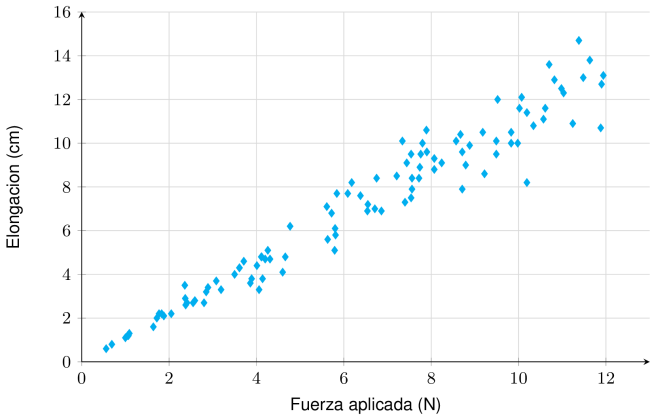

El comportamiento de la elongación respecto a la fuerza aplicada es

## Answerlist

- de tipo lineal y con mayor dispersion cuanto mayor sea la fuerza aplicada.
- de tipo lineal y con mayor dispersion cuanto mayor sea el estiramiento.
- cuadratico y con mayor dispersion cuanto mayor sea la fuerza aplicada.
- cuadratico y con mayor dispersion cuanto mayor sea el estiramiento.

# Solution

Para analizar el comportamiento de la elongación respecto a la fuerza aplicada, debemos observar dos aspectos clave en la gráfica de dispersión:

**1. Tipo de relación (de tipo lineal vs cuadratico):**

La relación entre la fuerza y la elongación sigue la Ley de Hooke:

$$x = \frac{F}{k}$$

donde $x$ es la elongación, $F$ es la fuerza aplicada y $k$ es la constante del resorte. Esta es una función **de tipo lineal** (proporcionalidad directa). En la gráfica se observa claramente una tendencia rectilínea ascendente.

**2. Patrón de dispersión:**

Observando la gráfica:

- En fuerzas pequeñas (cercanas a 0-2 N): los puntos están más concentrados
- En fuerzas grandes (cercanas a 10-12 N): los puntos muestran mayor variabilidad

Esto indica que **la dispersión es proporcional a la fuerza aplicada**, no a el estiramiento. Físicamente, esto se explica porque la incertidumbre en la aplicación de fuerzas mayores es más difícil de controlar, y pequeñas variaciones en la fuerza aplicada producen mayores fluctuaciones en la medición.

**Conclusión:**

El comportamiento es **de tipo lineal** (Ley de Hooke) y **con mayor dispersion cuanto mayor sea la fuerza aplicada** (mayor variabilidad en fuerzas grandes).

## Answerlist

- **Verdadero**. La relación es de tipo lineal (Ley de Hooke) y la dispersión aumenta proporcionalmente a la fuerza aplicada.
- **Falso**. Aunque la relación es de tipo lineal, la dispersión NO aumenta con el estiramiento sino con la fuerza aplicada.
- **Falso**. La relación NO es cuadratico (es de tipo lineal según la Ley de Hooke).
- **Falso**. La relación NO es cuadratico (es de tipo lineal) y la dispersión NO depende de el estiramiento.

# Meta-information

exname: elongacion_resorte_ley_hooke_interpretacion_representacion_n2_v1 extype: schoice exsolution: 1000 exshuffle: TRUE exsection: Estadistica/Graficas de Dispersion